# Omega Task

Study Group 19

2020-10-20

# 1 Omega Group plc- Pay Discrimination

At the last board meeting of Omega Group Plc., the headquarters of a large multinational company, the issue was raised that women were being discriminated in the company, in the sense that the salaries were not the same for male and female executives. A quick analysis of a sample of 50 employees (of which 24 men and 26 women) revealed that the average salary for men was about 8,700 higher than for women. This seemed like a considerable difference, so it was decided that a further analysis of the company salaries was warranted.

Our job has been focused on performing an analysis in order to find out whether there is indeed a significant difference between the salaries of men and women, and whether the difference is due to discrimination or whether it is based on another, possibly valid, determining factor.

## 1.1 We have worked with the following data:

```r
setwd("C:/Users/mayss/Documents/LBS_Term1/Data Analytics for Finance/session6-workshop3")

omega <- read_csv(file='data/omega.csv')
glimpse(omega) # examine the data frame
```

```
## Rows: 50
## Columns: 3
## $ salary     <dbl> 81894, 69517, 68589, 74881, 65598, 76840, 78800, 70033, ...
## $ gender     <chr> "male", "male", "male", "male", "male", "male", "male", ...
## $ experience <dbl> 16, 25, 15, 33, 16, 19, 32, 34, 1, 44, 7, 14, 33, 19, 24...
```

## 1.2 Relationship Salary - Gender ?

Calculate summary statistics on salary by gender. Also, create and print a dataframe where, for each gender, you show the mean, SD, sample size, the t-critical, the SE, the margin of error, and the low/high endpoints of a 95% condifence interval

```r
# Summary Statistics of salary by gender:
mosaic::favstats (salary ~ gender, data=omega)
```

```
##   gender   min    Q1 median    Q3   max  mean   sd  n missing
## 1 female 47033 60338  64618 70033 78800 64543 7567 26       0
## 2   male 54768 68331  74675 78568 84576 73239 7463 24       0
```

```r
# We now calculate the t-critical value, the standard error, the margin of error and the low/high endpoints of a 95% condifence interval:

omegastats<-omega%>%
select(salary,gender)%>%
  group_by(gender)%>%
  summarise(
    mean=mean(salary), # mean calculation
    SD=sd(salary), # standard deviation calculation
    SampleSize=n(), # sample size counting
    t_crit=qt(0.975,SampleSize-1), # t-critical value calculation
    SE=SD/sqrt(SampleSize), # standard error calculation
    MarginError=t_crit*SE, # margin error calculation
    Lowend=mean-MarginError, # low end point of the confidence interval
    Highend=mean+MarginError) # high end point of the confidence interval

omegastats
```

```
## # A tibble: 2 x 9
##   gender   mean    SD SampleSize t_crit    SE MarginError Lowend Highend
##   <chr>   <dbl> <dbl>      <int>  <dbl> <dbl>       <dbl>  <dbl>   <dbl>
## 1 female 64543. 7567.         26   2.06 1484.       3056. 61486.  67599.
## 2 male   73239. 7463.         24   2.07 1523.       3151. 70088.  76390.
```

> What can you conclude from your analysis?

It can be stated that there is a significant difference since the confidence intervals do not overlap. The high end of female salaries is 67,599 whereas the low end for male salaries is 70,088.

We will now use hypothesis testing analysis:

```r
# hypothesis testing using t.test()

t.test(salary ~ gender, data = omega)
```

```
##
##  Welch Two Sample t-test
##
## data:  salary by gender
## t = -4, df = 48, p-value = 2e-04
## alternative hypothesis: true difference in means is not equal to 0
## 95 percent confidence interval:
##  -12973  -4420
## sample estimates:
## mean in group female   mean in group male
##                64543                73239
```

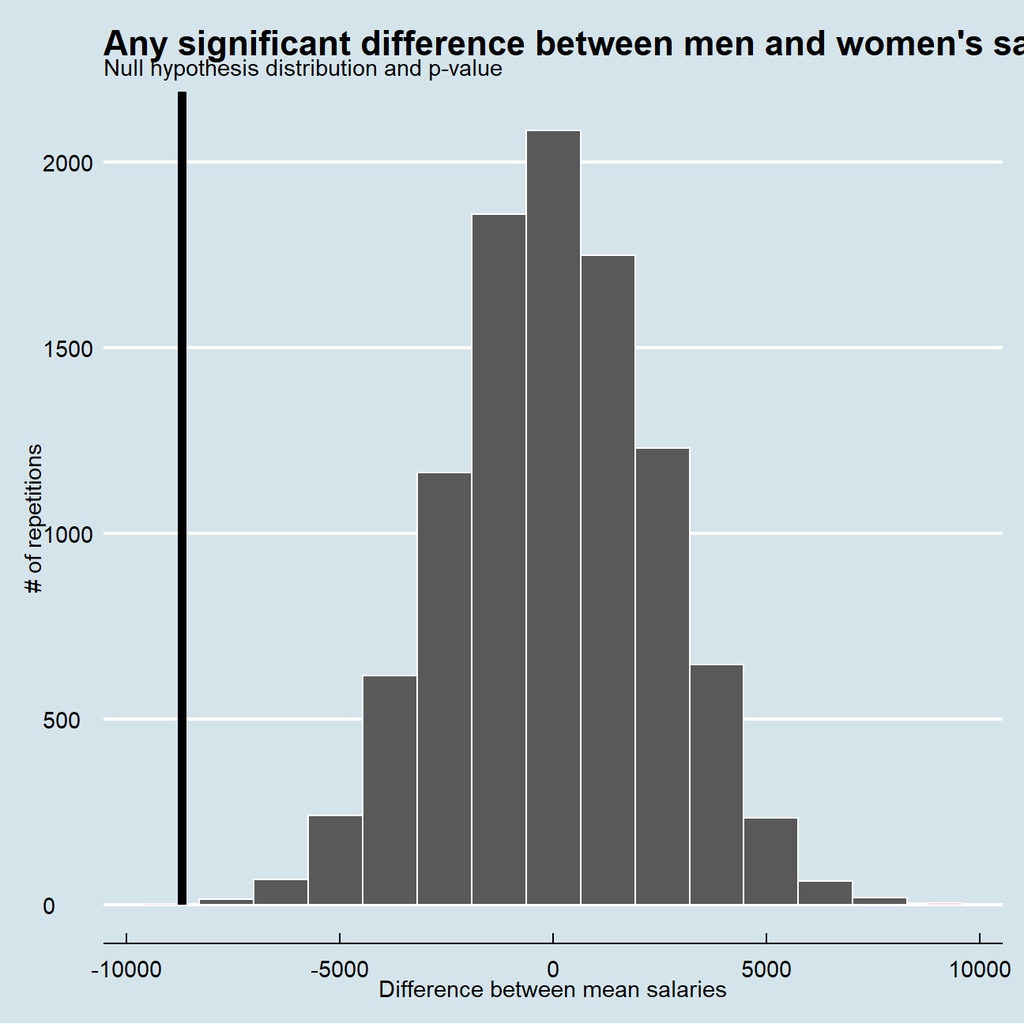

```r
# hypothesis testing using infer package

initialize_null <-omega%>%
specify(salary ~ gender)%>%
calculate(stat="diff in means",order=c("female","male"))

#Simulate the hypothesis test

salaries_null<-omega%>%
  specify(salary ~ gender)%>%
  hypothesize(null="independence")%>%
  generate(reps=10000,type="permute")%>%
  calculate(stat="diff in means",order=c("female","male"))

#Plotting the distribution and obtaining p value

salaries_null %>% visualize() +
  shade_p_value(obs_stat = initialize_null, direction = "two-sided", color="black")+
  labs(x="Difference between mean salaries",y="# of repetitions",title="Any significant difference between men and women's salaries?",subtitle="Null hypothesis distribution and p-value")+theme_economist()
```

```r
#Getting the p value

salaries_null %>% get_p_value(obs_stat = initialize_null, direction = "two_sided")
```

```
## # A tibble: 1 x 1
##   p_value
##     <dbl>
## 1  0.0004
```

> What can you conclude from your analysis?

## 1.3 Relationship Experience - Gender?

```r
# Summary Statistics of salary by gender
favstats (experience ~ gender, data=omega)
```

```
##   gender min    Q1 median   Q3 max  mean    sd  n missing
## 1 female   0  0.25    3.0 14.0  29  7.38  8.51 26       0
## 2   male   1 15.75   19.5 31.2  44 21.12 10.92 24       0
```

```r
omegastats2<-omega%>%
select(experience,gender)%>%
  group_by(gender)%>%
  summarise(
    mean=mean(experience), #mean calculation
    SD=sd(experience), # standard deviation calculation
    SampleSize=n(), # sample size counting
    t_crit=qt(0.975,SampleSize-1), # t critical calculation
    SE=SD/sqrt(SampleSize), # standard error calculation
  MarginError=t_crit*SE, # margin error calculation
  LowEnd=mean-MarginError, # low end of the confidence interval
  HighEnd=mean+MarginError) # high end of the confidence interval

omegastats2
```

```
## # A tibble: 2 x 9
##   gender  mean    SD SampleSize t_crit    SE MarginError LowEnd HighEnd
##   <chr>  <dbl> <dbl>      <int>  <dbl> <dbl>       <dbl>  <dbl>   <dbl>
## 1 female  7.38  8.51         26   2.06  1.67        3.44   3.95    10.8
## 2 male   21.1  10.9          24   2.07  2.23        4.61  16.5     25.7
```

Based on this evidence, can you conclude that there is a significant difference between the experience of the male and female executives?

We now perform the same analysis with hypothesis testing:

```r
# Hypothesis testing using t.test()
t.test(experience ~ gender, data = omega)
```

```
##
##  Welch Two Sample t-test
##
## data:  experience by gender
## t = -5, df = 43, p-value = 1e-05
## alternative hypothesis: true difference in means is not equal to 0
## 95 percent confidence interval:
##  -19.35  -8.13
## sample estimates:
## mean in group female   mean in group male
##                 7.38                21.12
```

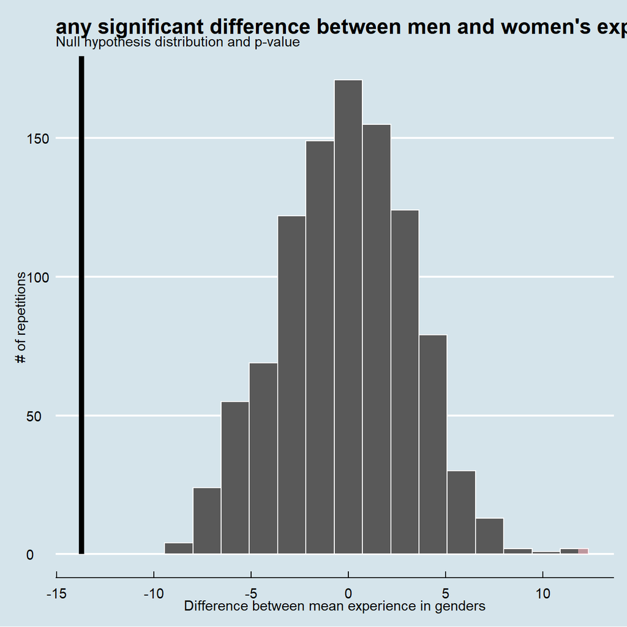

```r
# Hypothesis testing using infer package

initialize_null <- omega %>%
specify(experience ~ gender)%>%
calculate(stat="diff in means",order=c("female","male"))

#Simulate hypothesis testing

experience_null <- omega %>%
  specify(experience ~ gender) %>%
  hypothesize(null="independence") %>%
  generate(reps=1000,type="permute") %>%
  calculate(stat="diff in means",order=c("male","female"))

#Plotting the distribution and getting p value

experience_null %>% visualize() +
  shade_p_value(obs_stat = initialize_null, direction = "two-sided", color ="black")+
    labs(x="Difference between mean experience in genders",y="# of repetitions",title="any significant difference between men and women's experience?",subtitle="Null hypothesis distribution and p-value")+theme_economist()
```

```r
#Obtaining the p value

experience_null %>% get_p_value(obs_stat = initialize_null, direction = "two_sided")
```

```
## # A tibble: 1 x 1
##   p_value
##     <dbl>
## 1       0
```

We get the same conclusions as in the analysis above, further analysis is required before reaching a final conclusion.

## 1.4 Relationship Salary - Experience ?

We draw a scatterplot to visually inspect the data:

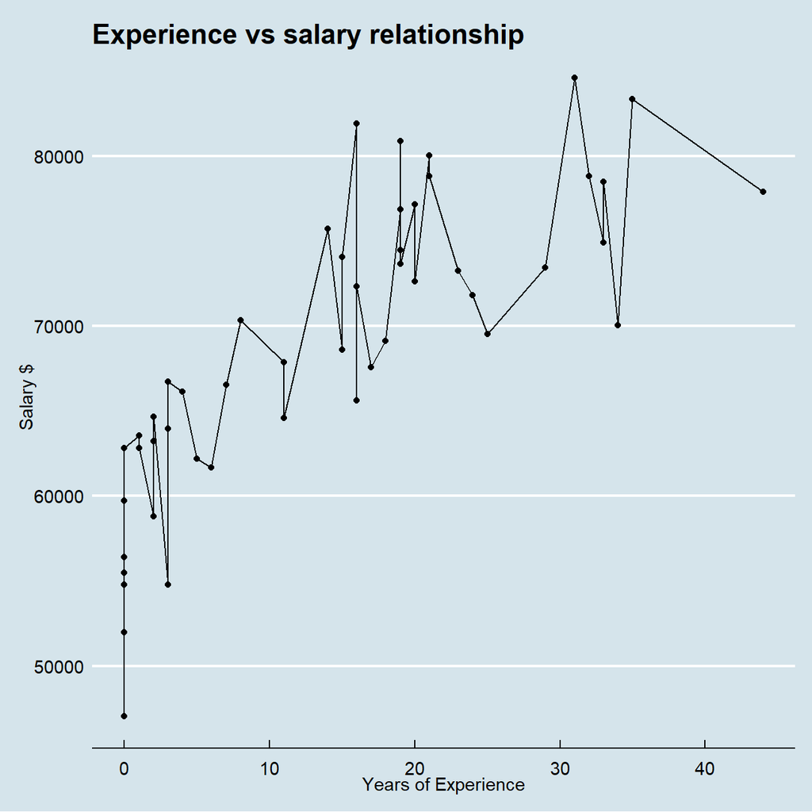

```r
omega %>%
ggplot(aes(x=experience,y=salary)) + theme_economist() + geom_point() + geom_line() + labs(title="Experience vs salary relationship",x="Years of Experience",y="Salary $")
```

## 1.5 Check correlations between the data

You can use `GGally:ggpairs()` to create a scatterplot and correlation matrix. Essentially, we change the order our variables will appear in and have the dependent variable (Y), salary, as last in our list. We then pipe the dataframe to `ggpairs()` with `aes` arguments to colour by `gender` and make ths plots somewhat transparent (`alpha = 0.3`).

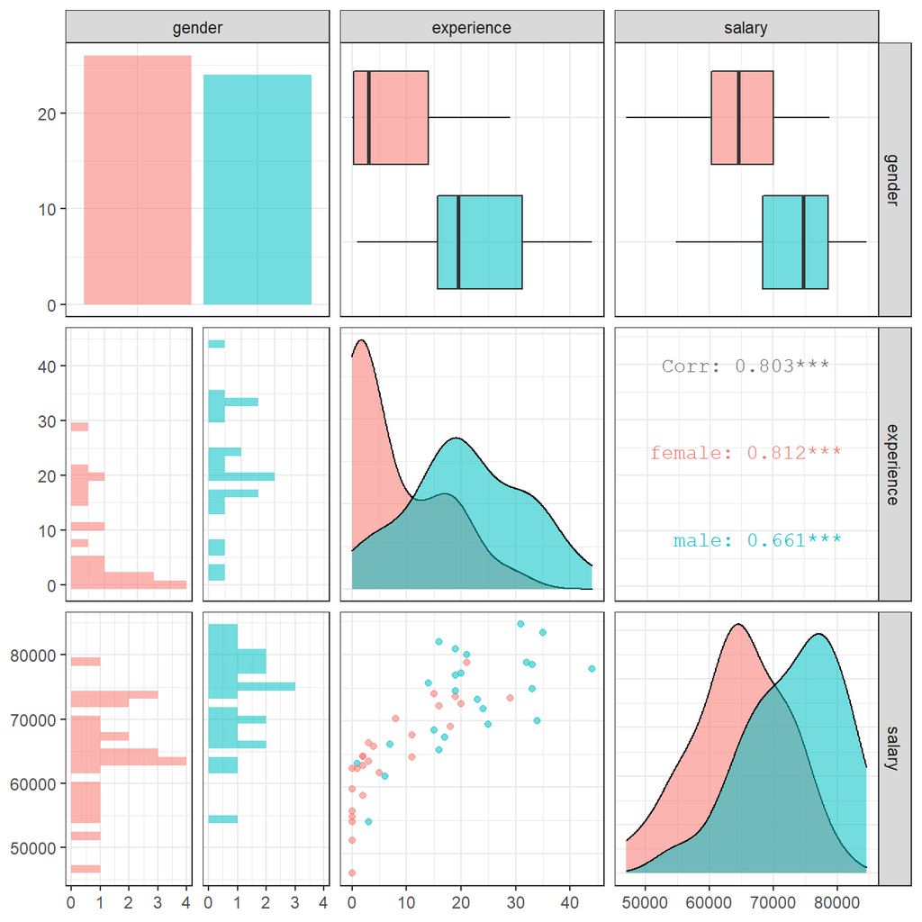

```r
omega %>%
  select(gender, experience, salary) %>% #order variables they will appear in ggpairs()
  ggpairs(aes(colour=gender, alpha = 0.3))+
  theme_bw()
```

> Look at the salary vs experience scatterplot. What can you infer from this plot?